# Maximizing TURF profit through different closure strategies

November 16, 2016

## **Project Set Up**

- A 100 km<sup>2</sup> TURF (Territorial Use Rights for Fishing), in a 10 by 10 km polygon.
- The fishers have heard about an option to enhance the productivity and the income by closing fishing grounds within the TURF (i.e. a TURF-reserve).
- By having a no-take area, the TURF will benefit from the spillover (i.e. organisms that step out of the reserve).
- The community seeked consultation to find the optimum way in which they can maximize profits.

## **Strategies**

1. **Permanent closure**: Close a percentage of the TURF for the whole time of the concession and get benefits from spillover.
2. **Temporal closure**: Close a percentage of the TURF for \(T*\) years, allowing the population to recover, then open the reserve and allow fish for a year before closing again.

## **Assumptions**

- The TURF is divided into parcels of 1 by 1 km.
- Each parcel of the concessioned area has a starting density of \[N_0 = \frac{K}{2}\]
- Movement wrapped at the edges of the TURF (Ovando *et al.*, 2016).
- Organisms are recruited once a year, with no age or size structure.
- Fishing effort outside the reserve is equal for every parcel.
- Price and costs are constant through time.

## **Equations**

\[N_{i,j,t+1} = N_{i,j,t} + N_{i,j,t}r\left(1-\left(\frac{N_{i,j,t}}{K}\right)\right) - U_{i,j,t} + M_{i,j,t} - E_{i,j,t}\]

Where:

\(N_{i,j,t}\) = Number of extractable lobsters in parcel *i, j* at time *t*

\(r\) = Population growth rate

\(K\) = Parcel carrying capacity

\(U_{i,j,t}\) = Number of lobsters extracted from parcel *i, j* at time *t*

\(M_{i,j,t}\) = Number of lobsters migrating into parcel *i, j* at time *t*

\(E_{i,j,t}\) = Number of lobsters migrating out of parcel *i, j* at time *t*

\[U_{i,j,t} = uN_{i,j,t}\]

\[E_{i,j,t} = m\left((1-u_{i,j,t})N_{i,j,t}\right)\]

\[M_{i,j,t} = \left(\frac{m}{4}(1-u_{i,j,t})\right)(N_{i-1,j,t} + N_{i+1,j,t} + N_{i,j-1,t} + N_{i,j+1,t})\]

Where:

\(u\) is the percentage of lobsters captured each year

\(m\) is the percentage of the lobsters that move out of a parcel each year

\[C_t = \sum_{i=1}^{n} \sum_{j=1}^{n} u_{i,j,t}N_{i,j,t} = \sum_{i=1}^{n} \sum_{j=1}^{n} U_{i,j,t}\]

\[R_t = C_tp-c\]

Where:

\(C_t\) represents catches at time *t*

\(R_t\) represents profits at time *t*

\(p\) is equal to the price of a lobster

\(c\) is the cost of fishing in a year

## **Data**

- Data from Quintana Roo provided by Comunidad y Biodiversidad A.C. (COBI).
- Data colected through transects inside the reserves.
- Parameters *r* and *K* were estimated optimizing model fit with solver. \[N_{t+1}=N_t+rN_t\left(1-\frac{N_t}{K}\right)\]
- Parameters *m*, *u*, *p* and *c* were selected based on our knowledge.

## **Parameters**

- Growth rate (\(r\)) = 1.0834
- Carrying capacity (\(K\)) = 0.0532 organisms/m<sup>2</sup>
- Movement rate (\(m\)) = 0.5
- Catch rate (\(u\)) = 0.6
- Price (\(p\)) = US$ 20/lobster
- Cost (\(c\)) = US$ 730/year
- Discount rate (\(d\)) = 0.05

## Strategy 1 - Permanent Closure

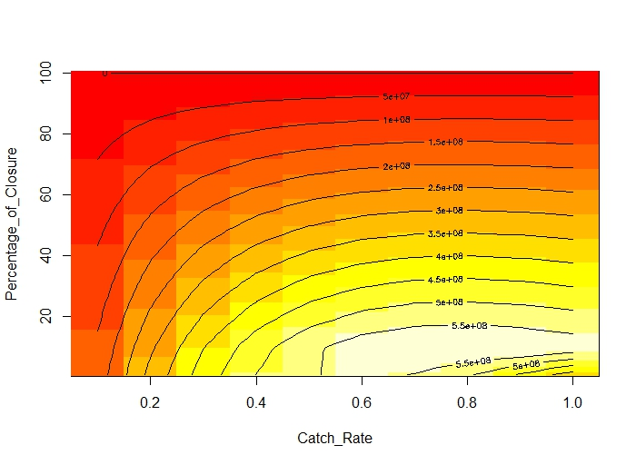

## Strategy 2 - Temporal Closure

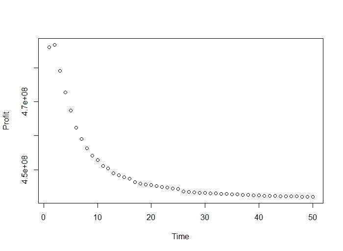

## Conclusion

- You can make a good amount of money fishing lobster!
- No-take areas can maximize the profits of a fishery.
- You're better off living from the spillover of a no-take area than doing a rotation strategy and harvesting the entire TURF.

## Questions and Comments?

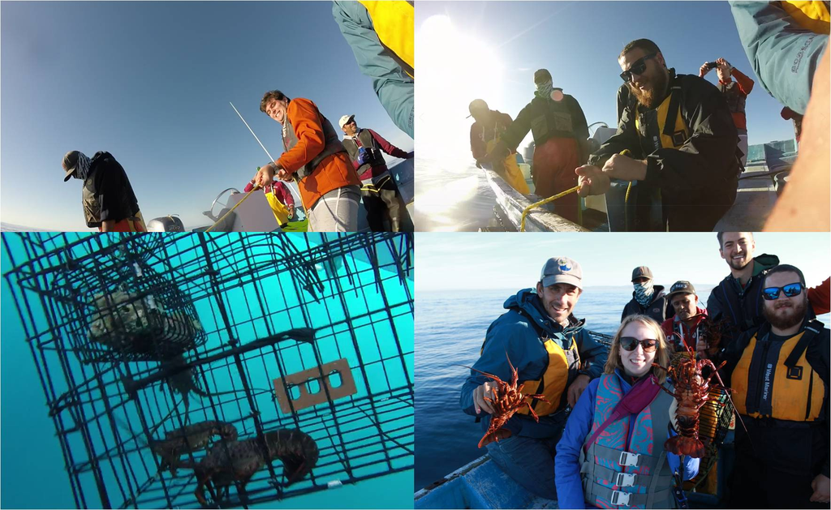